# Intro to R

DATA 299: Sports Analytics - Hitchman

# Activity Setup

1. Open RStudio
2. Create a new script
3. Save the script as ‘Act2_{FirstinitialLastname}’ in your shared course folder
4. Then, add code to your script to answer the following questions. Use comments as necessary so I know what you’re doing.
5. When you are finished, email me a link to your solution script. Please use subject DATA 299 Activity 2 Solution

# Load Data into your session

In this activity we consider hitting statistics from Major League Baseball from the 2024 season (April to October, 2024). To load the data into your session, run the following code in your script

```
hit <- read.csv("https://mphitchman.com/stats/sports/data/hit24.csv")
```

## Q1. Data Overview

> 1. How many observations? How many variables? Any missing values? .

```r
dim(hit)
```

```
## [1] 649  29
```

```r
colSums(is.na(hit))
```

```
## Name Bats  MLB  Age    G   PA   AB    H    D    T   HR    R  RBI    K   BB   SB
##    0    0    0    0    0    0    0    0    0    0    0    0    0    0    0    0
##   CS  GDP  HBP   SH   SF   RC  Pos  AVG  OBP  SLG  OPS WOBA  WAR
##    0    0    0    0    0    0   21    0    0    0    0    0    0
```

> 2. How many players scored at least 100 runs?

```r
sum(hit$R>=100)
```

```
## [1] 12
```

> 3. Which players scored at least 100 runs?

```r
hit$Name[which(hit$R>=100)]
```

```
##  [1] "Aaron Judge"      "Bobby Witt Jr."   "Shohei Ohtani"    "Juan Soto"
##  [5] "Gunnar Henderson" "Francisco Lindor" "Jarren Duran"     "Jose Ramirez"
##  [9] "Elly De La Cruz"  "Marcus Semien"    "Corbin Carroll"   "Kyle Schwarber"
```

> 4. How many lefties? How many righties? How many switch hitters?

```r
table(hit$Bats)
```

```
##
##   B   L   R
##  67 220 362
```

# Load the tidyverse into your session

```
library(tidyverse)
```

Recall, the tidyverse contains useful packages for managing and visualizing data such as

- dplyr
- ggplot

A brief list of commonly used `dplyr` action verbs:

| dplyr command | Description |
| --- | --- |
| `select()` | selecting columns (variables) |
| `filter()` | filter (subset) rows |
| `mutate()` | create new variables (columns) |
| `group_by()` | group the data |
| `summarize()` | summarize or aggregate the data |
| `arrange()` | sort the data |
| `join()` | joining data frames |
| `recode()` | recoding a variable |

## Q2 Filter the data frame to include just those hitters that had at least 350 plate appearances (`PA`), and make a histogram of the wOBA variable. What is the mean of the `WOBA` values?

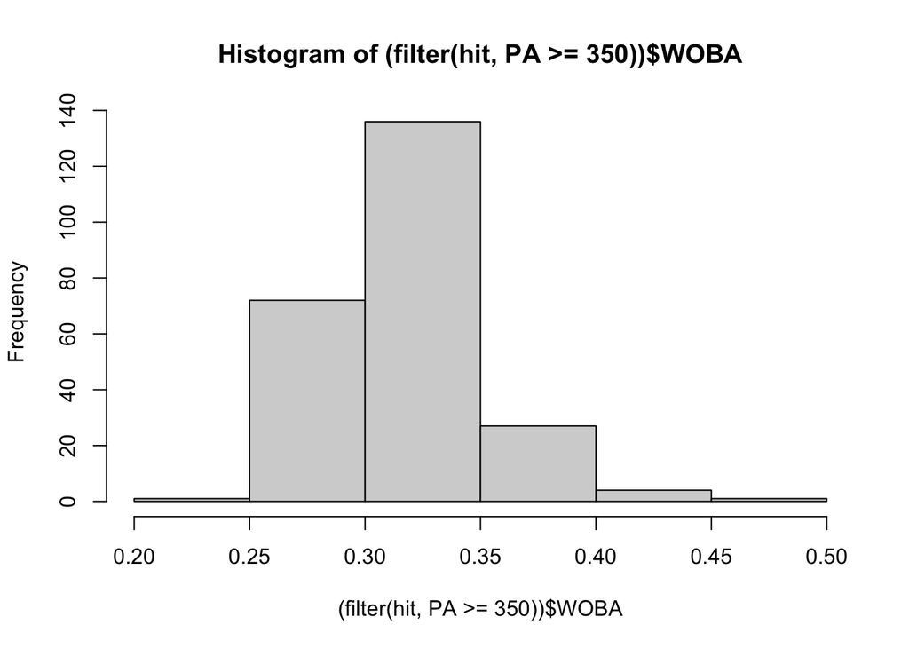

```r
hist((hit |> filter(PA>=350))$WOBA)
```

```r
mean((hit |> filter(PA>=350))$WOBA)
```

```
## [1] 0.3187884
```

## Q3 Make a nice table output of the top 20 HR hitters. Provide the name, the plate appearances, the home runs, and the home run percentage for each of these hitters (hr% = hr/PA)

```r
hit |> arrange(desc(HR)) |> select(Name,PA,HR) |> head(20) |> mutate('hr%' = round(HR/PA*100,1)) |> kbl(booktabs = TRUE,escape = FALSE) %>%kable_classic(full_width = FALSE)
```

| Name | PA | HR | hr% |
| --- | --- | --- | --- |
| Aaron Judge | 704 | 58 | 8.2 |
| Shohei Ohtani | 731 | 54 | 7.4 |
| Anthony Santander | 665 | 44 | 6.6 |
| Juan Soto | 713 | 41 | 5.8 |
| Jose Ramirez | 682 | 39 | 5.7 |
| Brent Rooker | 614 | 39 | 6.4 |
| Marcell Ozuna | 688 | 39 | 5.7 |
| Kyle Schwarber | 692 | 38 | 5.5 |
| Gunnar Henderson | 719 | 37 | 5.1 |
| Ketel Marte | 583 | 36 | 6.2 |
| Yordan Alvarez | 635 | 35 | 5.5 |
| Cal Raleigh | 628 | 34 | 5.4 |
| Pete Alonso | 695 | 34 | 4.9 |
| Francisco Lindor | 689 | 33 | 4.8 |
| Teoscar Hernandez | 652 | 33 | 5.1 |
| Bobby Witt Jr. | 709 | 32 | 4.5 |
| Willy Adames | 688 | 32 | 4.7 |
| Tyler O’Neill | 473 | 31 | 6.6 |
| Josh Naylor | 633 | 31 | 4.9 |
| Vladimir Guerrero Jr. | 697 | 30 | 4.3 |

## Q4 Primary position

Create a new column that gives a player’s primary defensive position. We define a player’s primary position to be associated with the first number appearing in the `Pos` column, using the convention that

| num | position |
| --- | --- |
| 2 | catcher |
| 3 | first base |
| 4 | second base |
| 5 | third base |
| 6 | shortstop |
| 7 | left field |
| 8 | center field |
| 9 | right field |
| NA | designated hitter |

```r
hit$Pos[is.na(hit$Pos)]<-0
hit$Pos <- as.character(hit$Pos)
hit <- hit |> mutate(prim_pos = substr(Pos,1,1)) |> mutate(prim_pos = recode(prim_pos,'0'='dh','2'='c','3'='1b','4'='2b','5'='3b','6'='ss','7'='lf','8'='cf','9'='rf'))
hit |> group_by(prim_pos) |> summarize(WAR=sum(WAR)) |> kbl() |> kable_classic(full_width=F)
```

| prim_pos | WAR |
| --- | --- |
| 1b | 41.4873 |
| 2b | 53.4299 |
| 3b | 61.4072 |
| c | 72.9150 |
| cf | 90.0848 |
| dh | 17.3721 |
| lf | 70.1212 |
| rf | 50.2835 |
| ss | 112.2221 |

##Q5 Restricting hitters to thoes with at least 350 plate appaearaces, construct side-by-side boxplots grouped by primary position for slugging percentage (SLG). Does the plot suggest that the big sluggers tend to be in the corner positions (RF, LF, 3B, 1B, and DH)?

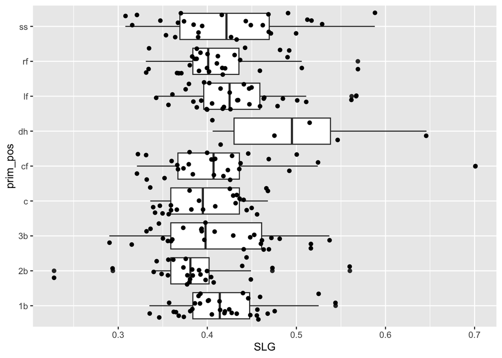

```r
ggplot(hit |> filter(PA>=350),aes(x=SLG,y=prim_pos))+geom_boxplot()+geom_jitter()
```